# SVL Project

```python
import pandas as pd
import numpy as np
```

```python
#1.1 A
df1=pd.read_csv("/Users/ananthb/Downloads/Normal.csv")
df1.head()
```

|  | P_incidence | P_tilt | L_angle | S_slope | P_radius | S_Degree | Class |
| --- | --- | --- | --- | --- | --- | --- | --- |
| 0 | 38.505273 | 16.964297 | 35.112814 | 21.540976 | 127.632875 | 7.986683 | Normal |
| 1 | 54.920858 | 18.968430 | 51.601455 | 35.952428 | 125.846646 | 2.001642 | Normal |
| 2 | 44.362490 | 8.945435 | 46.902096 | 35.417055 | 129.220682 | 4.994195 | Normal |
| 3 | 48.318931 | 17.452121 | 48.000000 | 30.866809 | 128.980308 | -0.910941 | Normal |
| 4 | 45.701789 | 10.659859 | 42.577846 | 35.041929 | 130.178314 | -3.388910 | Normal |

```python
df2=pd.read_csv("/Users/ananthb/Downloads/Type_S.csv")
df2.head()
```

|  | P_incidence | P_tilt | L_angle | S_slope | P_radius | S_Degree | Class |
| --- | --- | --- | --- | --- | --- | --- | --- |
| 0 | 74.377678 | 32.053104 | 78.772013 | 42.324573 | 143.560690 | 56.125906 | Type_S |
| 1 | 89.680567 | 32.704435 | 83.130732 | 56.976132 | 129.955476 | 92.027277 | Type_S |
| 2 | 44.529051 | 9.433234 | 52.000000 | 35.095817 | 134.711772 | 29.106575 | Type_S |
| 3 | 77.690577 | 21.380645 | 64.429442 | 56.309932 | 114.818751 | 26.931841 | Type_S |
| 4 | 76.147212 | 21.936186 | 82.961502 | 54.211027 | 123.932010 | 10.431972 | Type_S |

```python
df3=pd.read_csv("/Users/ananthb/Downloads/Type_H.csv")
df3.head()
```

|  | P_incidence | P_tilt | L_angle | S_slope | P_radius | S_Degree | Class |
| --- | --- | --- | --- | --- | --- | --- | --- |
| 0 | 63.027817 | 22.552586 | 39.609117 | 40.475232 | 98.672917 | -0.254400 | Type_H |
| 1 | 39.056951 | 10.060991 | 25.015378 | 28.995960 | 114.405425 | 4.564259 | Type_H |
| 2 | 68.832021 | 22.218482 | 50.092194 | 46.613539 | 105.985135 | -3.530317 | Type_H |
| 3 | 69.297008 | 24.652878 | 44.311238 | 44.644130 | 101.868495 | 11.211523 | Type_H |
| 4 | 49.712859 | 9.652075 | 28.317406 | 40.060784 | 108.168725 | 7.918501 | Type_H |

```python
#1.1 b
print('Normal  :',df1.shape )
print('Type  S :',df2.shape )
print('Type  H :',df3.shape )
```

```
Normal  : (100, 7)
Type  S : (150, 7)
Type  H : (60, 7)
```

#1.1 c In All 3 dataframes , All features names are same ,differing in values depends on Class column Class values are not in same Spelling/Format , they are given in shorter format.

```python
#1.1 d
df1.info(),df2.info(),df3.info()
```

```
<class 'pandas.core.frame.DataFrame'>
RangeIndex: 100 entries, 0 to 99
Data columns (total 7 columns):
 #   Column       Non-Null Count  Dtype
---  ------       --------------  -----
 0   P_incidence  100 non-null    float64
 1   P_tilt       100 non-null    float64
 2   L_angle      100 non-null    float64
 3   S_slope      100 non-null    float64
 4   P_radius     100 non-null    float64
 5   S_Degree     100 non-null    float64
 6   Class        100 non-null    object
dtypes: float64(6), object(1)
memory usage: 5.6+ KB
<class 'pandas.core.frame.DataFrame'>
RangeIndex: 150 entries, 0 to 149
Data columns (total 7 columns):
 #   Column       Non-Null Count  Dtype
---  ------       --------------  -----
 0   P_incidence  150 non-null    float64
 1   P_tilt       150 non-null    float64
 2   L_angle      150 non-null    float64
 3   S_slope      150 non-null    float64
 4   P_radius     150 non-null    float64
 5   S_Degree     150 non-null    float64
 6   Class        150 non-null    object
dtypes: float64(6), object(1)
memory usage: 8.3+ KB
<class 'pandas.core.frame.DataFrame'>
RangeIndex: 60 entries, 0 to 59
Data columns (total 7 columns):
 #   Column       Non-Null Count  Dtype
---  ------       --------------  -----
 0   P_incidence  60 non-null     float64
 1   P_tilt       60 non-null     float64
 2   L_angle      60 non-null     float64
 3   S_slope      60 non-null     float64
 4   P_radius     60 non-null     float64
 5   S_Degree     60 non-null     float64
 6   Class        60 non-null     object
dtypes: float64(6), object(1)
memory usage: 3.4+ KB
```

```
(None, None, None)
```

```python
# 1.1 E
df1['Class'].value_counts()
```

```
Normal    73
Nrmal     27
Name: Class, dtype: int64
```

```python
df2['Class'].value_counts()
```

```
Type_S    133
tp_s       17
Name: Class, dtype: int64
```

```python
df3['Class'].value_counts() # Class feature has two classes with misspelling
```

```
Type_H    37
type_h    23
Name: Class, dtype: int64
```

```python
#1.2 A
df1.Class="Normal"
df2.Class="Type_S"
df3.Class="Type_H"
```

```python
#1.2 B
df=pd.concat([df1,df2,df3])
df
```

|  | P_incidence | P_tilt | L_angle | S_slope | P_radius | S_Degree | Class |
| --- | --- | --- | --- | --- | --- | --- | --- |
| 0 | 38.505273 | 16.964297 | 35.112814 | 21.540976 | 127.632875 | 7.986683 | Normal |
| 1 | 54.920858 | 18.968430 | 51.601455 | 35.952428 | 125.846646 | 2.001642 | Normal |
| 2 | 44.362490 | 8.945435 | 46.902096 | 35.417055 | 129.220682 | 4.994195 | Normal |
| 3 | 48.318931 | 17.452121 | 48.000000 | 30.866809 | 128.980308 | -0.910941 | Normal |
| 4 | 45.701789 | 10.659859 | 42.577846 | 35.041929 | 130.178314 | -3.388910 | Normal |
| ... | ... | ... | ... | ... | ... | ... | ... |
| 55 | 47.657730 | 13.277385 | 36.679985 | 34.380345 | 98.249781 | 6.273012 | Type_H |
| 56 | 43.349606 | 7.467469 | 28.065483 | 35.882137 | 112.776187 | 5.753277 | Type_H |
| 57 | 46.855781 | 15.351514 | 38.000000 | 31.504267 | 116.250917 | 1.662706 | Type_H |
| 58 | 43.203185 | 19.663146 | 35.000000 | 23.540039 | 124.846109 | -2.919076 | Type_H |
| 59 | 48.109236 | 14.930725 | 35.564683 | 33.178512 | 124.056452 | 7.947905 | Type_H |

310 rows × 7 columns

```python
#1.2 C
df.sample(5)
```

|  | P_incidence | P_tilt | L_angle | S_slope | P_radius | S_Degree | Class |
| --- | --- | --- | --- | --- | --- | --- | --- |
| 99 | 33.841641 | 5.073991 | 36.641233 | 28.767649 | 123.945244 | -0.199249 | Normal |
| 82 | 34.756738 | 2.631740 | 29.504381 | 32.124998 | 127.139849 | -0.460894 | Normal |
| 5 | 83.933009 | 41.286305 | 62.000000 | 42.646703 | 115.012334 | 26.588100 | Type_S |
| 15 | 59.726140 | 7.724873 | 55.343485 | 52.001268 | 125.174221 | 3.235159 | Normal |
| 82 | 85.290173 | 18.278890 | 100.744220 | 67.011283 | 110.660701 | 58.884948 | Type_S |

```python
#1.2 D
(df.isnull().sum()/df.shape[0])*100 #No Null Values are there
```

```
P_incidence    0.0
P_tilt         0.0
L_angle        0.0
S_slope        0.0
P_radius       0.0
S_Degree       0.0
Class          0.0
dtype: float64
```

```python
# 1.2 E
df.describe().T
```

|  | count | mean | std | min | 25% | 50% | 75% | max |
| --- | --- | --- | --- | --- | --- | --- | --- | --- |
| P_incidence | 310.0 | 60.496653 | 17.236520 | 26.147921 | 46.430294 | 58.691038 | 72.877696 | 129.834041 |
| P_tilt | 310.0 | 17.542822 | 10.008330 | -6.554948 | 10.667069 | 16.357689 | 22.120395 | 49.431864 |
| L_angle | 310.0 | 51.930930 | 18.554064 | 14.000000 | 37.000000 | 49.562398 | 63.000000 | 125.742385 |
| S_slope | 310.0 | 42.953831 | 13.423102 | 13.366931 | 33.347122 | 42.404912 | 52.695888 | 121.429566 |
| P_radius | 310.0 | 117.920655 | 13.317377 | 70.082575 | 110.709196 | 118.268178 | 125.467674 | 163.071041 |
| S_Degree | 310.0 | 26.296694 | 37.559027 | -11.058179 | 1.603727 | 11.767934 | 41.287352 | 418.543082 |

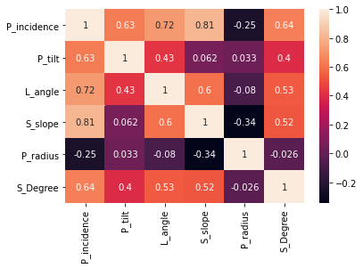

```python
#1.3 A
import seaborn as sns
sns.heatmap(df.corr(),annot=True)
```

#1.3 B P_incidence is positively correlated with [P_tilt,L_angle,S_angle,S_degree] apart from P_radius L_angle is positively correlated with P-incidence,S_slope & slightly with S_Degree P_radius & S_slope is slightly negatively correlated P_radius & S_degree are poorly correlated similar for L_angle & P_radius

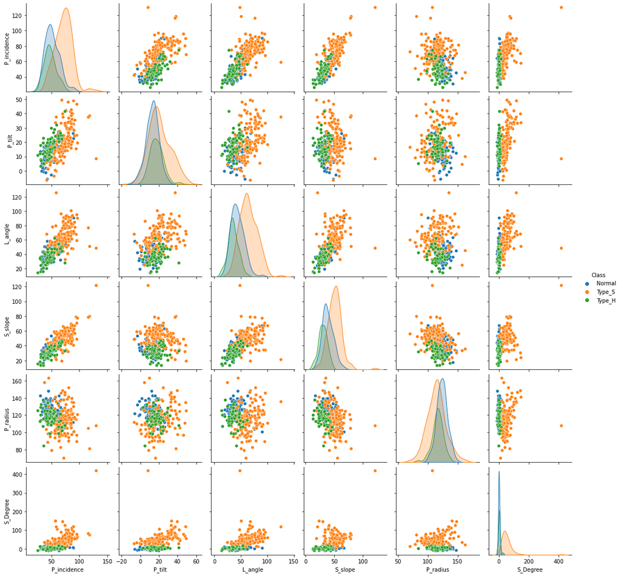

```python
#1.3 C
sns.pairplot(df,hue='Class')
```

# We can see linear relationship between few features such as S_angle & P_incidence #In case of P_incidence apart from P_radius they possess linear relationship which we already saw in correlation # Normal class possess similar characteristic as Type_S & Type_H as it was overlapped by both Type_S & Type_H

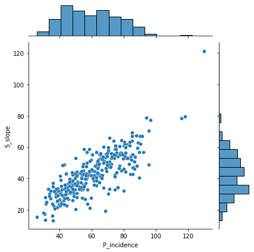

```python
#1.3 D
sns.jointplot(df['P_incidence'],df['S_slope'])
```

P_incidence & S_slope have linear relationship and they are positively Skewed Data i.e, Leptokurtic

```python
df['P_incidence'].skew()
```

```
0.5204398948625644
```

```python
df['S_slope'].skew()
```

```
0.7925766941630672
```

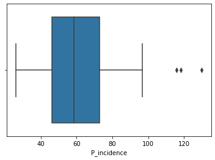

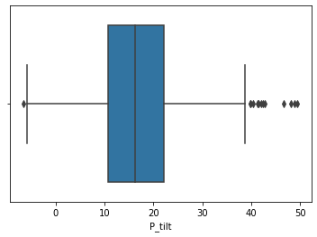

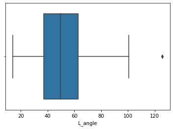

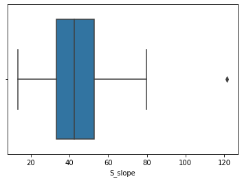

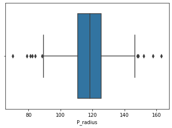

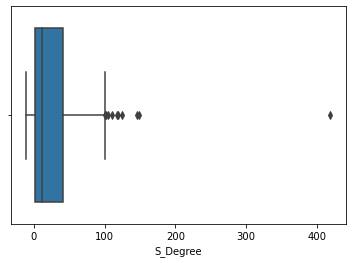

```python
#1.3 E
import matplotlib.pyplot as plt
for i in df.columns[:-1]:
        sns.boxplot(df[i])
        plt.show()
```

```python
# Few Outliers can be found in most of the features
```

```python
df.head()
```

|  | P_incidence | P_tilt | L_angle | S_slope | P_radius | S_Degree | Class |
| --- | --- | --- | --- | --- | --- | --- | --- |
| 0 | 38.505273 | 16.964297 | 35.112814 | 21.540976 | 127.632875 | 7.986683 | Normal |
| 1 | 54.920858 | 18.968430 | 51.601455 | 35.952428 | 125.846646 | 2.001642 | Normal |
| 2 | 44.362490 | 8.945435 | 46.902096 | 35.417055 | 129.220682 | 4.994195 | Normal |
| 3 | 48.318931 | 17.452121 | 48.000000 | 30.866809 | 128.980308 | -0.910941 | Normal |
| 4 | 45.701789 | 10.659859 | 42.577846 | 35.041929 | 130.178314 | -3.388910 | Normal |

```python
#1.4 A
X=df.iloc[:,:-1]
Y= df.iloc[:,-1:]
X.head(),Y.head()
```

```
(   P_incidence     P_tilt    L_angle    S_slope    P_radius  S_Degree
 0    38.505273  16.964297  35.112814  21.540976  127.632875  7.986683
 1    54.920858  18.968430  51.601455  35.952428  125.846646  2.001642
 2    44.362490   8.945435  46.902096  35.417055  129.220682  4.994195
 3    48.318931  17.452121  48.000000  30.866809  128.980308 -0.910941
 4    45.701789  10.659859  42.577846  35.041929  130.178314 -3.388910,
     Class
 0  Normal
 1  Normal
 2  Normal
 3  Normal
 4  Normal)
```

```python
from sklearn.preprocessing import StandardScaler
ss=StandardScaler()
X=pd.DataFrame(ss.fit_transform(X),columns=X.columns)
X.head()
```

|  | P_incidence | P_tilt | L_angle | S_slope | P_radius | S_Degree |
| --- | --- | --- | --- | --- | --- | --- |
| 0 | -1.277922 | -0.057898 | -0.907904 | -1.597803 | 0.730468 | -0.488288 |
| 1 | -0.324010 | 0.142672 | -0.017786 | -0.522437 | 0.596124 | -0.647896 |
| 2 | -0.937559 | -0.860412 | -0.271475 | -0.562386 | 0.849889 | -0.568091 |
| 3 | -0.707649 | -0.009077 | -0.212206 | -0.901920 | 0.831811 | -0.725568 |
| 4 | -0.859732 | -0.688835 | -0.504914 | -0.590377 | 0.921914 | -0.791650 |

```python
#1.4 B
from sklearn.model_selection import train_test_split
X_train, X_test, y_train, y_test = train_test_split(X, Y, test_size=0.2, random_state=7)
```

```python
from sklearn.neighbors import KNeighborsClassifier as KNN
from sklearn.metrics import accuracy_score,confusion_matrix,classification_report
from sklearn.metrics import recall_score
```

```python
#1.4 C Base Model Randomly choosing 3
kn=KNN(3)
kn.fit(np.array(X_train),np.ravel(y_train))
y_pred=kn.predict(X_test)
```

```python
#1.4 D
accuracy_score(y_test,y_pred)
```

```
0.7096774193548387
```

```python
confusion_matrix(y_test,y_pred)
```

```
array([[17,  1,  3],
       [ 8,  7,  0],
       [ 5,  1, 20]])
```

```python
print(classification_report(y_test,y_pred))
```

```
              precision    recall  f1-score   support

      Normal       0.57      0.81      0.67        21
      Type_H       0.78      0.47      0.58        15
      Type_S       0.87      0.77      0.82        26

    accuracy                           0.71        62
   macro avg       0.74      0.68      0.69        62
weighted avg       0.74      0.71      0.71        62
```

```python
#1.5 A
max_accuracy={}
max_recall={}
score=[]
methods=['manhattan','euclidean','cosine','jaccard','minkowski','hamming']
for i in range(1,20):
    for j in methods:
        kn=KNN(i,metric=j)
        kn.fit(np.array(X_train),np.ravel(y_train))
        y_pred=kn.predict(np.array(X_test))
        max_accuracy[str(i)+'_'+str(j)]=accuracy_score(np.array(y_test),np.array(y_pred))
        score.append(accuracy_score(np.array(y_test),np.array(y_pred)))
        max_recall[str(i)+'_'+str(j)]=recall_score(y_test,y_pred,average='micro')
```

```python
max(max_accuracy,key=max_accuracy.get)
```

```
'11_manhattan'
```

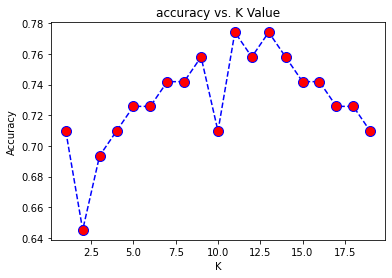

```python
score=[]

for i in range(1,20):
        kn=KNN(i,metric='manhattan')
        kn.fit(np.array(X_train),np.ravel(y_train))
        y_pred=kn.predict(np.array(X_test))
        score.append(accuracy_score(np.array(y_test),np.array(y_pred)))
plt.plot(range(1,20),score,color = 'blue',linestyle='dashed',
         marker='o',markerfacecolor='red', markersize=10)
plt.title('accuracy vs. K Value')
plt.xlabel('K')
plt.ylabel('Accuracy')
plt.show()
```

```python
MSE={}
for j,k in max_accuracy.items():
    MSE[j]=1-k
```

```python
min(MSE,key=MSE.get)
```

```
'11_manhattan'
```

```python
#1.5 B
kn=KNN(11,metric='manhattan')
kn.fit(np.array(X_train),np.ravel(y_train))
ypred=kn.predict(X_test)
print(classification_report(y_test,ypred))
```

```
              precision    recall  f1-score   support

      Normal       0.63      0.81      0.71        21
      Type_H       0.90      0.60      0.72        15
      Type_S       0.88      0.85      0.86        26

    accuracy                           0.77        62
   macro avg       0.80      0.75      0.76        62
weighted avg       0.80      0.77      0.78        62
```

```python
accuracy_score(np.array(y_test),np.array(ypred))
```

```
0.7741935483870968
```

#1.5 C Comparing base model we can after hyperparamater tuning, the accuracy has increased by 7% Metric used is Manhattan & Neighbors for voting is 11

```python
#2.1 A
b1=pd.read_csv("/Users/ananthb/Downloads/Data1.csv")
b2=pd.read_csv("/Users/ananthb/Downloads/Data2.csv")
```

```python
b1.head()
```

|  | ID | Age | CustomerSince | HighestSpend | ZipCode | HiddenScore | MonthlyAverageSpend | Level |
| --- | --- | --- | --- | --- | --- | --- | --- | --- |
| 0 | 1 | 25 | 1 | 49 | 91107 | 4 | 1.6 | 1 |
| 1 | 2 | 45 | 19 | 34 | 90089 | 3 | 1.5 | 1 |
| 2 | 3 | 39 | 15 | 11 | 94720 | 1 | 1.0 | 1 |
| 3 | 4 | 35 | 9 | 100 | 94112 | 1 | 2.7 | 2 |
| 4 | 5 | 35 | 8 | 45 | 91330 | 4 | 1.0 | 2 |

```python
b2.head()
```

|  | ID | Mortgage | Security | FixedDepositAccount | InternetBanking | CreditCard | LoanOnCard |
| --- | --- | --- | --- | --- | --- | --- | --- |
| 0 | 1 | 0 | 1 | 0 | 0 | 0 | NaN |
| 1 | 2 | 0 | 1 | 0 | 0 | 0 | NaN |
| 2 | 3 | 0 | 0 | 0 | 0 | 0 | NaN |
| 3 | 4 | 0 | 0 | 0 | 0 | 0 | NaN |
| 4 | 5 | 0 | 0 | 0 | 0 | 1 | NaN |

```python
#2.1 B
b1.info()
```

```
<class 'pandas.core.frame.DataFrame'>
RangeIndex: 5000 entries, 0 to 4999
Data columns (total 8 columns):
 #   Column               Non-Null Count  Dtype
---  ------               --------------  -----
 0   ID                   5000 non-null   int64
 1   Age                  5000 non-null   int64
 2   CustomerSince        5000 non-null   int64
 3   HighestSpend         5000 non-null   int64
 4   ZipCode              5000 non-null   int64
 5   HiddenScore          5000 non-null   int64
 6   MonthlyAverageSpend  5000 non-null   float64
 7   Level                5000 non-null   int64
dtypes: float64(1), int64(7)
memory usage: 312.6 KB
```

```python
b2.info()
```

```
<class 'pandas.core.frame.DataFrame'>
RangeIndex: 5000 entries, 0 to 4999
Data columns (total 7 columns):
 #   Column               Non-Null Count  Dtype
---  ------               --------------  -----
 0   ID                   5000 non-null   int64
 1   Mortgage             5000 non-null   int64
 2   Security             5000 non-null   int64
 3   FixedDepositAccount  5000 non-null   int64
 4   InternetBanking      5000 non-null   int64
 5   CreditCard           5000 non-null   int64
 6   LoanOnCard           4980 non-null   float64
dtypes: float64(1), int64(6)
memory usage: 273.6 KB
```

```python
b1.shape,b2.shape
```

```
((5000, 8), (5000, 7))
```

```python
#2.1 C
df=b1.merge(b2,how='inner',on='ID')
df.head()
```

|  | ID | Age | CustomerSince | HighestSpend | ZipCode | HiddenScore | MonthlyAverageSpend | Level | Mortgage | Security | FixedDepositAccount | InternetBanking | CreditCard | LoanOnCard |
| --- | --- | --- | --- | --- | --- | --- | --- | --- | --- | --- | --- | --- | --- | --- |
| 0 | 1 | 25 | 1 | 49 | 91107 | 4 | 1.6 | 1 | 0 | 1 | 0 | 0 | 0 | NaN |
| 1 | 2 | 45 | 19 | 34 | 90089 | 3 | 1.5 | 1 | 0 | 1 | 0 | 0 | 0 | NaN |
| 2 | 3 | 39 | 15 | 11 | 94720 | 1 | 1.0 | 1 | 0 | 0 | 0 | 0 | 0 | NaN |
| 3 | 4 | 35 | 9 | 100 | 94112 | 1 | 2.7 | 2 | 0 | 0 | 0 | 0 | 0 | NaN |
| 4 | 5 | 35 | 8 | 45 | 91330 | 4 | 1.0 | 2 | 0 | 0 | 0 | 0 | 1 | NaN |

```python
# 2.1 D
df[['CreditCard', 'InternetBanking', 'FixedDepositAccount', 'Security', 'Level', 'HiddenScore']]=df[['CreditCard', 'InternetBanking', 'FixedDepositAccount', 'Security', 'Level', 'HiddenScore']].astype(object)
```

```python
df.info()
```

```
<class 'pandas.core.frame.DataFrame'>
Int64Index: 5000 entries, 0 to 4999
Data columns (total 14 columns):
 #   Column               Non-Null Count  Dtype
---  ------               --------------  -----
 0   ID                   5000 non-null   int64
 1   Age                  5000 non-null   int64
 2   CustomerSince        5000 non-null   int64
 3   HighestSpend         5000 non-null   int64
 4   ZipCode              5000 non-null   int64
 5   HiddenScore          5000 non-null   object
 6   MonthlyAverageSpend  5000 non-null   float64
 7   Level                5000 non-null   object
 8   Mortgage             5000 non-null   int64
 9   Security             5000 non-null   object
 10  FixedDepositAccount  5000 non-null   object
 11  InternetBanking      5000 non-null   object
 12  CreditCard           5000 non-null   object
 13  LoanOnCard           4980 non-null   float64
dtypes: float64(2), int64(6), object(6)
memory usage: 585.9+ KB
```

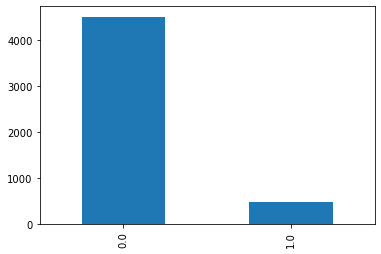

```python
#2.2 A
import matplotlib.pyplot as plt
df['LoanOnCard'].value_counts().plot(kind='bar')

# There is class imbalance i.e Frequency of class 1 is less in this dataset .
#We need to oversampling for class 1 or undersampling for class 0
```

```python
#2.2 B
df.isnull().sum()/len(df)
# Few null values are in LoanOnCard feature
```

```
ID                     0.000
Age                    0.000
CustomerSince          0.000
HighestSpend           0.000
ZipCode                0.000
HiddenScore            0.000
MonthlyAverageSpend    0.000
Level                  0.000
Mortgage               0.000
Security               0.000
FixedDepositAccount    0.000
InternetBanking        0.000
CreditCard             0.000
LoanOnCard             0.004
dtype: float64
```

```python
df['LoanOnCard'].fillna(value=np.random.choice(df['LoanOnCard']),inplace=True)
#As there is class imbalance using random function for imputation instead of mode
```

```python
df['LoanOnCard'].isnull().sum()
```

```
0
```

```python
#2.2 C
cat=df.select_dtypes(include=object)
cat.head()
```

|  | HiddenScore | Level | Security | FixedDepositAccount | InternetBanking | CreditCard |
| --- | --- | --- | --- | --- | --- | --- |
| 0 | 4 | 1 | 1 | 0 | 0 | 0 |
| 1 | 3 | 1 | 1 | 0 | 0 | 0 |
| 2 | 1 | 1 | 0 | 0 | 0 | 0 |
| 3 | 1 | 2 | 0 | 0 | 0 | 0 |
| 4 | 4 | 2 | 0 | 0 | 0 | 1 |

```python
for j in cat.columns:
    print(j,df[j].unique())

#There is no special characters in the categorical columns
```

```
HiddenScore [4 3 1 2]
Level [1 2 3]
Security [1 0]
FixedDepositAccount [0 1]
InternetBanking [0 1]
CreditCard [0 1]
```

```python
df['LoanOnCard']=df['LoanOnCard'].astype(object)
```

```python
df.drop(['ID','ZipCode'],axis=1,inplace=True)
```

[output not shown]

```python
from sklearn.preprocessing import StandardScaler
num=df.select_dtypes(exclude=object)
ss=StandardScaler()
dfs=pd.DataFrame(ss.fit_transform(num),columns=num.columns)
dfs.head()
```

|  | Age | CustomerSince | HighestSpend | MonthlyAverageSpend | Mortgage |
| --- | --- | --- | --- | --- | --- |
| 0 | -1.774417 | -1.666078 | -0.538229 | -0.193385 | -0.555524 |
| 1 | -0.029524 | -0.096330 | -0.864109 | -0.250611 | -0.555524 |
| 2 | -0.552992 | -0.445163 | -1.363793 | -0.536736 | -0.555524 |
| 3 | -0.901970 | -0.968413 | 0.569765 | 0.436091 | -0.555524 |
| 4 | -0.901970 | -1.055621 | -0.625130 | -0.536736 | -0.555524 |

```python
cat_df=df.select_dtypes(include=object)
```

```python
dff=pd.concat([dfs,cat_df.iloc[:,:-1]],axis=1)
dff.head()
```

|  | Age | CustomerSince | HighestSpend | MonthlyAverageSpend | Mortgage | HiddenScore | Level | Security | FixedDepositAccount | InternetBanking | CreditCard |
| --- | --- | --- | --- | --- | --- | --- | --- | --- | --- | --- | --- |
| 0 | -1.774417 | -1.666078 | -0.538229 | -0.193385 | -0.555524 | 4 | 1 | 1 | 0 | 0 | 0 |
| 1 | -0.029524 | -0.096330 | -0.864109 | -0.250611 | -0.555524 | 3 | 1 | 1 | 0 | 0 | 0 |
| 2 | -0.552992 | -0.445163 | -1.363793 | -0.536736 | -0.555524 | 1 | 1 | 0 | 0 | 0 | 0 |
| 3 | -0.901970 | -0.968413 | 0.569765 | 0.436091 | -0.555524 | 1 | 2 | 0 | 0 | 0 | 0 |
| 4 | -0.901970 | -1.055621 | -0.625130 | -0.536736 | -0.555524 | 4 | 2 | 0 | 0 | 0 | 1 |

```python
# 2. 3 A
X=dff
Y=df['LoanOnCard']
```

```python
X.head()
```

|  | Age | CustomerSince | HighestSpend | MonthlyAverageSpend | Mortgage | HiddenScore | Level | Security | FixedDepositAccount | InternetBanking | CreditCard |
| --- | --- | --- | --- | --- | --- | --- | --- | --- | --- | --- | --- |
| 0 | -1.774417 | -1.666078 | -0.538229 | -0.193385 | -0.555524 | 4 | 1 | 1 | 0 | 0 | 0 |
| 1 | -0.029524 | -0.096330 | -0.864109 | -0.250611 | -0.555524 | 3 | 1 | 1 | 0 | 0 | 0 |
| 2 | -0.552992 | -0.445163 | -1.363793 | -0.536736 | -0.555524 | 1 | 1 | 0 | 0 | 0 | 0 |
| 3 | -0.901970 | -0.968413 | 0.569765 | 0.436091 | -0.555524 | 1 | 2 | 0 | 0 | 0 | 0 |
| 4 | -0.901970 | -1.055621 | -0.625130 | -0.536736 | -0.555524 | 4 | 2 | 0 | 0 | 0 | 1 |

```python
Y.head()
```

```
0    1.0
1    0.0
2    0.0
3    0.0
4    0.0
Name: LoanOnCard, dtype: object
```

```python
#2.3 B
from sklearn.model_selection import train_test_split
xtrain,xtest,ytrain,ytest=train_test_split(X,Y,test_size=0.25)
```

```python
print(xtrain.shape),print(ytrain.shape),print(xtest.shape),print(ytest.shape)
```

```
(3750, 11)
(3750,)
(1250, 11)
(1250,)
```

```
(None, None, None, None)
```

```python
xtrain
```

|  | Age | CustomerSince | HighestSpend | MonthlyAverageSpend | Mortgage | HiddenScore | Level | Security | FixedDepositAccount | InternetBanking | CreditCard |
| --- | --- | --- | --- | --- | --- | --- | --- | --- | --- | --- | --- |
| 94 | 1.715370 | 1.647835 | 1.025998 | 0.035515 | -0.555524 | 1 | 1 | 0 | 0 | 0 | 0 |
| 3799 | -0.727481 | -0.793996 | -0.646856 | -0.994537 | -0.555524 | 4 | 1 | 0 | 0 | 0 | 1 |
| 2095 | 0.144966 | 0.078086 | 2.177443 | 0.722217 | -0.555524 | 4 | 3 | 0 | 0 | 0 | 0 |
| 3289 | 0.406700 | 0.426919 | -0.646856 | -0.937312 | 1.283152 | 1 | 1 | 0 | 0 | 1 | 1 |
| 4547 | 0.406700 | 0.426919 | -0.907560 | -0.708412 | -0.555524 | 2 | 2 | 0 | 0 | 1 | 0 |
| ... | ... | ... | ... | ... | ... | ... | ... | ... | ... | ... | ... |
| 202 | -1.338194 | -1.491662 | -0.125447 | 0.035515 | -0.555524 | 4 | 2 | 0 | 0 | 1 | 0 |
| 3677 | 1.191902 | 1.124585 | -0.668581 | -0.937312 | -0.555524 | 2 | 1 | 0 | 0 | 0 | 1 |
| 846 | 0.493944 | 0.601336 | 0.417688 | 0.436091 | -0.555524 | 1 | 1 | 0 | 0 | 1 | 0 |
| 1255 | -1.599928 | -1.666078 | 0.135258 | -0.193385 | 1.263487 | 2 | 3 | 0 | 0 | 1 | 1 |
| 1501 | -1.338194 | -1.404454 | -0.842384 | -0.937312 | -0.555524 | 2 | 2 | 1 | 0 | 0 | 1 |

3750 rows × 11 columns

```python
# 2.3 C
from sklearn.linear_model import LogisticRegression

lr=LogisticRegression()
lr.fit(xtrain,ytrain.astype(int))
pred=lr.predict(xtest)
```

```python
from sklearn.metrics import classification_report,accuracy_score,confusion_matrix,recall_score
```

```python
#2.3 D
print(classification_report(ytest.astype(int),pred))
```

```
              precision    recall  f1-score   support

           0       0.90      1.00      0.95      1129
           1       0.00      0.00      0.00       121

    accuracy                           0.90      1250
   macro avg       0.45      0.50      0.47      1250
weighted avg       0.82      0.90      0.86      1250
```

```python
print(confusion_matrix(ytest.astype(int),pred))
```

```
[[1129    0]
 [ 121    0]]
```

```python
# We can clearly see that due to class imbalance class 1 prediction is not available ,
# support number is verly low compared to class 0

#We need to do sampling to overcome this
```

```python
#2.3 E
from imblearn.over_sampling import SMOTE
oversample = SMOTE(sampling_strategy='minority')
Xc, yc = oversample.fit_resample(X,Y.astype(int))
```

```python
Counter(Y.astype(int))
```

```
Counter({1: 480, 0: 4520})
```

```python
Counter(yc)
#Now Class has been balanced for both the classes
```

```
Counter({1: 4520, 0: 4520})
```

```python
xtrain1,xtest1,ytrain1,ytest1=train_test_split(Xc,yc,test_size=0.25)
```

```python
#2.3 F
lr=LogisticRegression()
lr.fit(xtrain1,ytrain1.astype(int))
pred1=lr.predict(xtest1)
```

```python
# 2.3 G
print(classification_report(ytest1.astype(int),pred1))

# Accuracy score  has dropped a lot may be beacuse
# Now Class has been balanced , need to focus on accuracy by implementing non linear models
```

```
              precision    recall  f1-score   support

           0       0.55      0.53      0.54      1123
           1       0.55      0.57      0.56      1137

    accuracy                           0.55      2260
   macro avg       0.55      0.55      0.55      2260
weighted avg       0.55      0.55      0.55      2260
```

```python
#2.4 A
from sklearn.neighbors import KNeighborsClassifier
```

```python
knn=KNeighborsClassifier()
knn.fit(xtrain1,ytrain1.astype(int))
kn_pred=knn.predict(xtest1)
print(classification_report(ytest1.astype(int),kn_pred))
print(confusion_matrix(ytest1,kn_pred))
# Accuracy has increased better now
```

```
              precision    recall  f1-score   support

           0       0.98      0.68      0.80      1123
           1       0.76      0.98      0.86      1137

    accuracy                           0.83      2260
   macro avg       0.87      0.83      0.83      2260
weighted avg       0.87      0.83      0.83      2260

[[ 764  359]
 [  19 1118]]
```

```python
from sklearn import svm
sv = svm.SVC()
sv.fit(xtrain1,ytrain1.astype(int))
svc_pred=sv.predict(xtest1)
print(classification_report(ytest1.astype(int),svc_pred))
```

```
              precision    recall  f1-score   support

           0       0.67      0.51      0.58      1123
           1       0.61      0.76      0.67      1137

    accuracy                           0.63      2260
   macro avg       0.64      0.63      0.63      2260
weighted avg       0.64      0.63      0.63      2260
```

```python
AS KNN base modeliteslef  gives better accuracy compared to SVM, it will do better when it is tuned further
```

```python
#2.4 B
from sklearn.neighbors import KNeighborsClassifier

max_accuracy={}
max_recall={}
score=[]
methods=['manhattan','euclidean','cosine','jaccard','minkowski','hamming']
for i in range(1,20):
    for j in methods:
        kn=KNeighborsClassifier(i,metric=j)
        kn.fit(np.array(xtrain1),np.ravel(ytrain1))
        y_pred=kn.predict(np.array(xtest1))
        max_accuracy[str(i)+'_'+str(j)]=accuracy_score(np.array(ytest1.astype(int)),np.array(y_pred))
        score.append(accuracy_score(np.array(ytest1),np.array(y_pred)))
        max_recall[str(i)+'_'+str(j)]=recall_score(ytest1,y_pred,average='micro')
```

```python
max(max_accuracy,key=max_accuracy.get)
```

```
'1_manhattan'
```

```python
max_accuracy[max(max_recall,key=max_recall.get)]
```

```
0.911504424778761
```

```python
final=KNeighborsClassifier(1,metric='manhattan')
final.fit(np.array(xtrain1),np.ravel(ytrain1))
y_pred=final.predict(np.array(xtest1))
```

```python
#2.4 C
print(classification_report(y_pred,ytest1))
```

```
              precision    recall  f1-score   support

           0       0.85      0.96      0.91       997
           1       0.97      0.87      0.92      1263

    accuracy                           0.91      2260
   macro avg       0.91      0.92      0.91      2260
weighted avg       0.92      0.91      0.91      2260
```

```python
confusion_matrix(y_pred,ytest1)
```

```
array([[ 960,   37],
       [ 163, 1100]])
```

# 2.4 D

Comparing base model the accuracy score has increased better One of the Crucial thing we are targetting customers having loan , so we need to concentrate on false positive Comparing base model , FP rate has dropped very well , hence our final model is performing very well